# finalcode-Copy3

Reading Datase (covid_data.csv) In -Project is to predict Severity - Using Random Forest Method

I am using the covid_data.csv dataset -

I will start by importing Pandas Library and Below I am showing an extract of features from actual dataset.

```python
import pandas as pd
#import numpy as np
df = pd.read_csv("covid_data.csv")##reading dataset
df.head()##displaying first 5 rows
```

|  | Sample | Age | Sex | Severity | A1BG | A1CF | A2M | A2ML1 | A3GALT2 | A4GALT | ... | ZWILCH | ZWINT | ZXDA | ZXDB | ZXDC | ZYG11A | ZYG11B | ZYX | ZZEF1 | ZZZ3 |
| --- | --- | --- | --- | --- | --- | --- | --- | --- | --- | --- | --- | --- | --- | --- | --- | --- | --- | --- | --- | --- | --- |
| 0 | C1 | 39 | male | NonICU | 0.49 | 0.00 | 0.21 | 0.04 | 0.07 | 0.0 | ... | 2.84 | 4.22 | 0.95 | 1.63 | 15.51 | 0.06 | 8.17 | 363.01 | 19.17 | 6.05 |
| 1 | C2 | 63 | male | NonICU | 0.29 | 0.00 | 0.14 | 0.00 | 0.00 | 0.0 | ... | 3.55 | 12.15 | 0.60 | 1.15 | 15.62 | 0.14 | 8.20 | 399.80 | 15.72 | 4.12 |
| 2 | C3 | 33 | male | NonICU | 0.26 | 0.00 | 0.03 | 0.02 | 0.00 | 0.0 | ... | 1.34 | 2.79 | 0.18 | 0.32 | 17.67 | 0.28 | 3.62 | 430.35 | 13.95 | 1.81 |
| 3 | C4 | 49 | male | NonICU | 0.45 | 0.01 | 0.09 | 0.07 | 0.00 | 0.0 | ... | 3.71 | 5.87 | 1.40 | 2.21 | 15.61 | 0.27 | 7.88 | 209.25 | 14.78 | 7.15 |
| 4 | C5 | 49 | male | NonICU | 0.17 | 0.00 | 0.00 | 0.05 | 0.07 | 0.0 | ... | 1.44 | 4.46 | 0.28 | 0.55 | 9.34 | 0.07 | 5.96 | 272.91 | 8.69 | 2.70 |

5 rows × 19476 columns

Checking the Shape (amount of columns and rows) of dataset, - The code block below, shows the dimension of features in the dataset (126 observations, 19476 features). It's high dimensionality since m>>n .

```python
df.shape
```

```
(126, 19476)
```

I am now checking for what data types this dataset contains, i.e are they floart/string/integer type, from the information below we can sae that majority of dataset features are which is makes it easier for our method to work, but we have 1 int value and 3 object. I will need to review which are the object values and check if they can be converted to float, but first i need to review the data for missing or null values.

```python
df.info()
```

```
<class 'pandas.core.frame.DataFrame'>
RangeIndex: 126 entries, 0 to 125
Columns: 19476 entries, Sample to ZZZ3
dtypes: float64(19472), int64(1), object(3)
memory usage: 18.7+ MB
```

Block of code below is checking the dataset for any null or missing values. great news is that it has found 0 nan values, we can now easily proceed to next state of data processing

```python
##a=df.isna().sum()==0
df.isnull().values.any()
df.isnull().sum().sum()

##print(a)
```

```
0
```

```python
dataTypeSeries = df.dtypes
print(dataTypeSeries)
```

```
Sample       object
Age           int64
Sex          object
Severity     object
A1BG        float64
             ...
ZYG11A      float64
ZYG11B      float64
ZYX         float64
ZZEF1       float64
ZZZ3        float64
Length: 19476, dtype: object
```

block of code below separates features (X) from outcomes (y). We investigated earlier that we have 3 Object datatype. Severity has "ICU" and "NonICU" data , which i have replaced with 0's amd 1's. and then changed the feature to float type. Similary with Sex feature has "Female" , "Male" and "unknown" which i have then replaced with 0,1,2 and change object type to float.

Finally sample feature has value towards our aim, which is been dropped from X features alongside with Severity as it is good practice to Remove target variable from the Features (X).

```python
y = pd.DataFrame(df,columns=['Severity'])##Setting Severity as target variable y
y['Severity'].replace(['ICU','NonICU'],[0,1],inplace=True)
y['Severity'].astype('float')
X = df.drop(columns=['Severity','Sample'],axis = 1)##dropping the dependant variable
X['Sex'].replace(['female','male','unknown'],[0,1,2],inplace=True)
X['Sex'].astype('float')
#print(X['Sex'])
```

```
0      1.0
1      1.0
2      1.0
3      1.0
4      1.0
      ...
121    1.0
122    0.0
123    0.0
124    1.0
125    1.0
Name: Sex, Length: 126, dtype: float64
```

line below shows Outcome has changed from categorical to numerical

```python
y.head()
```

|  | Severity |
| --- | --- |
| 0 | 1 |
| 1 | 1 |
| 2 | 1 |
| 3 | 1 |
| 4 | 1 |

The line below shows the dimension of feature data (126 observations, 19474 features). It's high dimensionality since m<<n .

```python
X.shape
```

```
(126, 19474)
```

What we know so far- We have so far understood this is a high dimentional dataset with 19476 dataset - We have found that theres no nan values , We have converted all features that were object type to float and dropped the features which had no use for our method.

Our Issue - how to reduce these features - 19476 is massive amount of features our model has to go through which could be heavy for laptops/ computers would take time to run. Also could effect the accuracy of our model.

There is a commonly used method PCA-Principal Component Analysis (is an unsupervised, non-parametric statistical technique primarily used for dimensionality reduction in machine learning.) which is normally used to reduced the amount of features- the idea is bring down 19476 to under 100 features

After playing around with the number of features i want to keep for my X axis ( independent variables ), i decided to ask pca to reduce features down to 53 features to go into the model , you will see that i have put 53 n_components ( i asking pca on how many features i want it to down to).

I have then transformed the independent variable (X) with the reduced amount of features- the reason for this doing is to make sure our method does not hang with computing time and it is more efficient.

```python
from sklearn.decomposition import PCA

pca = PCA(n_components=53)
pca.fit(X)
print(pca.explained_variance_ratio_)
print(pca.components_)
X = pca.transform(X)
```

```
[5.64253005e-01 3.29034034e-01 3.16475453e-02 2.54408027e-02
 1.74957283e-02 1.23713109e-02 3.39026045e-03 2.39725529e-03
 2.10667163e-03 1.74339191e-03 1.39020900e-03 1.13737909e-03
 1.03514530e-03 7.39203422e-04 6.16685284e-04 5.16260797e-04
 3.96280273e-04 3.33903749e-04 2.97460367e-04 2.71375797e-04
 2.64795168e-04 2.33430966e-04 2.15761436e-04 2.04410986e-04
 1.90508308e-04 1.71577787e-04 1.48894055e-04 1.44333360e-04
 1.23298366e-04 1.12219805e-04 1.07308749e-04 9.75048981e-05
 9.20684251e-05 7.93015336e-05 6.63995075e-05 6.44011442e-05
 6.00689780e-05 5.73303941e-05 5.51209388e-05 5.36263396e-05
 4.93373815e-05 4.17388441e-05 3.96875480e-05 3.76145229e-05
 3.50291922e-05 3.21647425e-05 3.11264168e-05 2.93214526e-05
 2.63007810e-05 2.45037775e-05 2.38493258e-05 2.19994927e-05
 2.11338863e-05]
[[ 7.71905254e-06 -8.48665207e-07  5.31945139e-07 ... -3.73404289e-04
  -5.44467393e-06  2.30579359e-06]
 [ 7.11380268e-05 -2.75295873e-09 -2.24506288e-06 ...  7.13153963e-04
  -4.31245155e-05 -2.39520641e-05]
 [ 4.11215942e-05  2.25402924e-06  2.15683841e-06 ...  5.80244089e-04
  -5.82226568e-05 -1.16342819e-05]
 ...
 [-6.31196967e-03 -6.14041918e-05 -1.30936479e-05 ...  3.27051736e-03
  -4.09471146e-04 -7.32436814e-05]
 [-2.54705742e-03 -2.85387202e-04  6.56308226e-05 ... -1.15343740e-02
   2.36548563e-04  8.03958287e-05]
 [ 4.01583964e-03  8.17998322e-06 -2.74998627e-05 ... -6.87516444e-03
  -2.24299319e-04  1.43972956e-04]]
```

To confirm X axis has changed i am checking the shape of X. whith the result of 53 it matches the reduction made by pca- so our PCA has reduced the amount of features to put through our model.

```python
X.shape
```

```
(126, 53)
```

Splitting data into Training/Tuning-validation/testing set The block below splits our dataset into training and validation (test) sets. We keep validation set as unseen.

Tuning data is composed by 67% of data, the remaining 33% of data goes to the validation set. The variable random_state indicates the seed of the shuffling.

X_train - in this i have included all independent variables ,,these will be used to train the model, also as we have specified the test_size = 0.33, this means 67% of observations from your complete data will be used to train/fit the model and rest 33% will be used to test the model.X_test - The remaining 33% portion of the independent variables from the data which will not be used in the training phase and will be used to make predictions to test the accuracy of the model.This is the dependent variable which needs to be predicted by this model basically Severity, this can include category labels against your independent variables, we need to specify our dependent variable while training/fitting the model which will be Severity.y_test - This data has category labels for test data, i will be using this to calculate the accuracy showing the actual vs predicted result .

```python
import pandas as pd
from sklearn.model_selection import train_test_split
from sklearn.ensemble import RandomForestClassifier
from sklearn import metrics
import seaborn as sns
import matplotlib.pyplot as plt

X_train,X_test,y_train,y_test = train_test_split(X,y,test_size=0.33,random_state=1)
y_train=y_train.values.ravel()
```

```python
X_train.shape
```

```
(84, 53)
```

```python
y_train.shape
```

```
(84,)
```

Some important parameters defined by the RandomForestClassifier module are:

random_grid = { 'n_estimators': [100,200,300,400,500],>>This is the number of trees in the forest- the higher the number the better variance. , i kept it to maximum 500, it also increases the computing time as the number trees increases this is why i kept it to maximum 500 so it does not exhaust the pc. 'max_features': randint(1,53),>>Maximum features are 53 because thats we set by using pca function - this will be selecting number of features to consider in our method 'max_depth': [3,5,10,32,None], the maximum depth can be upto 32 , but i have decided to keep the maximum 32 (this is how deep can go). The deeper the tree, the more splits it has and it captures more information about the data. i have tried different variation.

'criterion':['gini','entropy'], This parameter is the function used to measure the quality of a split and it allows users to choose between ‘gini‘ or ‘entropy, I am using criterion to ensure that features when splitted are have a tidy splits and data is not messy. I have selected both criterion so when i choose the param it can decide which one is best to use.

'bootstrap':[True,False], 'min_samples_leaf':randint(1,4),

} The theory shows that the accuracy of random forest can be decomposed as:

[output not shown]

After selecting my parameters, I have then decided use these parameters in hypertuning method i created , In which i am using this paramters above (random_grid), In this function i have used randomisedSearchcv method to run through the parameters above.

Why am i using RandomisedSearchCV cross validation is simply because it is helping me choose the Best parameters that would suite my random forest method to try to get the best results. i.e it would tell me how many trees should my method have in n_estimatores , how deep the tree needs to be (depth)..etc , it would tell me which criterion works best with this dataset...etc. My idea is run this method to get the Best param and recall it using ht_params which i have defined to return, after running this method it should print the best parameters and numbers associated with, with this information i would run random forest again.

To this purpose:

The higher the value of n_estimators the better the variance term is reduced. However, also higher the computational time. A low value of max_features generates biased and uncorrelated trees, therefore the final model may contain some bias. An high value of max_features generates unbiased but correlated trees, therefore the final model may contain some variance. Conversely, a fine tuning may be needed to find the optimal value of max_features.

The code below does so.

```python
##Regression Model using RandomizedSearchCV

from sklearn.model_selection import RandomizedSearchCV
from scipy.stats import randint

rfc1 = RandomForestClassifier(n_jobs=-1)
rfc1.fit(X_train,y_train.ravel())

# create random grid
random_grid = {
 'n_estimators': [100,200,300,400,500],
 'max_features': randint(1,53),
 'max_depth': [3,5,10,32,None],
 'criterion':['gini','entropy'],
 'bootstrap':[True,False],
 'min_samples_leaf':randint(1,4),

 }
def hypertuning_rscv(rfc1,random_grid,nbr_iter,X,y):
    rfc_random = RandomizedSearchCV(estimator = rfc1, param_distributions = random_grid, n_iter = nbr_iter, cv = 5, verbose=2, random_state=42, n_jobs = -1)
    rfc_random.fit(X,y)
    ht_params =rfc_random.best_params_
    ht_score =rfc_random.best_score_
    return ht_params,ht_score

y_pred= rfc1.predict(X_test)

rf_parameters, rf_ht_score = hypertuning_rscv(rfc1,random_grid,50,X,y.values.ravel())
```

```
Fitting 5 folds for each of 50 candidates, totalling 250 fits
```

```
[Parallel(n_jobs=-1)]: Using backend LokyBackend with 12 concurrent workers.
[Parallel(n_jobs=-1)]: Done  17 tasks      | elapsed:    4.9s
[Parallel(n_jobs=-1)]: Done 138 tasks      | elapsed:   14.0s
[Parallel(n_jobs=-1)]: Done 250 out of 250 | elapsed:   21.1s finished
```

calling rf_ht_score to obtain the score for the random forest model above, we can clearly see score 0.75 leaves room for improvement as planned i am going to test the model parameters now with oob score and then with kfold cross validation and then pick the best model.

```python
rf_ht_score
```

```
0.7455384615384616
```

```python
rf_parameters
```

```
{'bootstrap': True,
 'criterion': 'gini',
 'max_depth': 10,
 'max_features': 9,
 'min_samples_leaf': 3,
 'n_estimators': 200}
```

```python
from sklearn.tree import DecisionTreeRegressor
from sklearn.metrics import accuracy_score

acc_train = []
acc_test = []


from sklearn import model_selection
# random forest model creation
rfc2 = RandomForestClassifier(n_jobs=-1,n_estimators=400,oob_score = True,bootstrap=True,criterion='entropy',max_depth=10,max_features=14, min_samples_leaf=1)
a=rfc2.fit(X_train,y_train)
# predictions
rfc_predict1 = rfc2.predict(X_test)
rfc2 = rfc2.score(X_test,y_test.values.ravel())
acc_train.append( accuracy_score(y_train, a.predict(X_train)) )
acc_test.append( a.oob_score_ )
print(acc_test)
print(accuracy_score)
print(accuracy_score)
```

```
[0.7619047619047619]
<function accuracy_score at 0x0000022470BD1940>
<function accuracy_score at 0x0000022470BD1940>
```

printing the results .. accuracy of 0.76 is not that great model is ok little improvement, i am now going to use crossvalscore(validation) to see if that improves the model instead of using oob score

```python
accuracies = pd.DataFrame({
                           "acc_test": acc_test})
accuracies.head()
```

|  | acc_test |
| --- | --- |
| 0 | 0.761905 |

```python
from sklearn.model_selection import cross_val_score
from sklearn.metrics import classification_report, confusion_matrix
```

```python
rfc3 = RandomForestClassifier(n_jobs=-1,n_estimators=400,bootstrap=True,criterion='entropy',max_depth=10,max_features=14, min_samples_leaf=1)
a=rfc3.fit(X_train,y_train.ravel())

a.fit(X_train,y_train)
k = 5
kf = model_selection.KFold(n_splits=k, random_state=None)
rfc_cv_score = cross_val_score(rfc3, X, y, cv=kf, scoring='roc_auc')
rfc3.fit(X_train,y_train.ravel())
rfc_predict2 = rfc3.predict(X_test)

rfc_cv_score.mean()
```

```
0.8031592534241975
```

I am now generating a report with all the scores for my final model to better understand and summarise the model

```python
print("=== Confusion Matrix ===")
print(confusion_matrix(y_test, rfc_predict2))
print('\n')
print("=== Classification Report ===")
print(classification_report(y_test, rfc_predict2))
print('\n')
print("=== All AUC Scores ===")
print(rfc_cv_score)
print('\n')
print("=== Mean AUC Score ===")
print("Mean AUC Score - Random Forest: ", rfc_cv_score.mean())
```

```
=== Confusion Matrix ===
[[14  7]
 [10 11]]


=== Classification Report ===
              precision    recall  f1-score   support

           0       0.58      0.67      0.62        21
           1       0.61      0.52      0.56        21

    accuracy                           0.60        42
   macro avg       0.60      0.60      0.59        42
weighted avg       0.60      0.60      0.59        42



=== All AUC Scores ===
[0.9112426  0.68421053 1.         0.69117647 0.72916667]


=== Mean AUC Score ===
Mean AUC Score - Random Forest:  0.8031592534241975
```

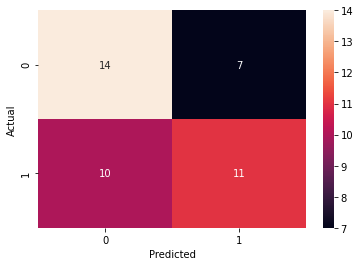

```python
confusion_matrix = pd.crosstab(y_test.values.ravel(), rfc_predict2, rownames=['Actual'], colnames=['Predicted'])
sns.heatmap(confusion_matrix, annot=True)
```

```python
test = pd.DataFrame({"actual": y_test.Severity.values,
                     "fitted": y_pred})
test
```

|  | actual | fitted |
| --- | --- | --- |
| 0 | 1 | 1 |
| 1 | 0 | 0 |
| 2 | 1 | 0 |
| 3 | 1 | 1 |
| 4 | 0 | 0 |
| 5 | 0 | 0 |
| 6 | 0 | 0 |
| 7 | 1 | 0 |
| 8 | 0 | 1 |
| 9 | 0 | 0 |
| 10 | 1 | 0 |
| 11 | 1 | 0 |
| 12 | 0 | 1 |
| 13 | 1 | 1 |
| 14 | 0 | 0 |
| 15 | 0 | 0 |
| 16 | 0 | 1 |
| 17 | 1 | 0 |
| 18 | 1 | 1 |
| 19 | 1 | 0 |
| 20 | 1 | 0 |
| 21 | 1 | 1 |
| 22 | 0 | 0 |
| 23 | 0 | 1 |
| 24 | 1 | 0 |
| 25 | 0 | 0 |
| 26 | 1 | 1 |
| 27 | 0 | 0 |
| 28 | 1 | 0 |
| 29 | 0 | 1 |
| 30 | 0 | 1 |
| 31 | 0 | 0 |
| 32 | 0 | 1 |
| 33 | 0 | 0 |
| 34 | 0 | 0 |
| 35 | 1 | 0 |
| 36 | 1 | 1 |
| 37 | 1 | 1 |
| 38 | 1 | 1 |
| 39 | 0 | 1 |
| 40 | 1 | 0 |
| 41 | 1 | 1 |

We can see below that the final model has a high bias and low variance, this clearly shows theres room for improvement still remain in our model. For future perference we need to aim to have lower bias compared to variance.

In case of Random Forest, we use multiple decision trees in parallel. The low bias and high variance property will be there of the decision tree will be there, but as we are using multiple decision trees in parallel,the high variance would be converted to low variance.

This is exactly what happened in our model, the variance dropped. In future improvement we will aim to improve the variance.

```python
from mlxtend.evaluate import bias_variance_decomp
y_train.reshape(84,1)


mse, bias, var = bias_variance_decomp(rfc3, X_train, y_train.ravel(), X_test, y_test.values.ravel(), loss='mse', random_seed=None)
# summarize results
print('MSE: %.3f' % mse)
print('Bias: %.3f' % bias)
print('Variance: %.3f' % var)
```

```
MSE: 0.370
Bias: 0.226
Variance: 0.145
```

Just to visualise one tree of the forest, to see how deep it is going - this is one of the reason why the variance has been affect as the depth increases the variance drops. The tree below is only one of the tree, it is just to show the visualisation of the tree

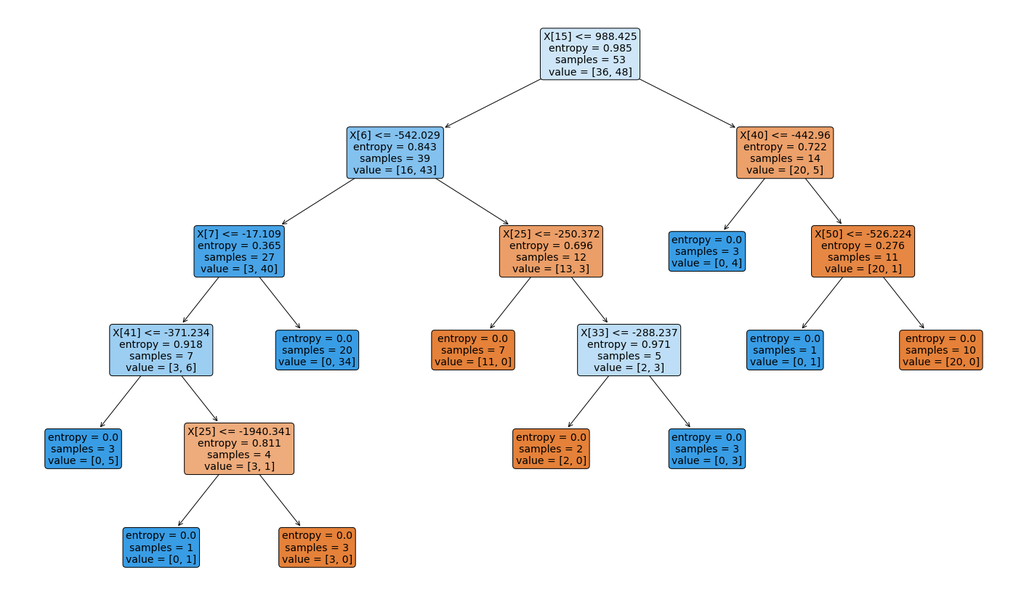

```python
import pydot
# Pull out one tree from the forest
Tree = rfc3.estimators_[5]
# Export the image to a dot file
from sklearn import tree
plt.figure(figsize=(25,15))
tree.plot_tree(Tree,filled=True,
              rounded=True,
              fontsize=14);
```

```python
from sklearn import metrics
import math
print('As we can see from the results below, Model performed better (has a better r2 results) then the model without \n')
print('Mean Absolute Error: With RandomisedSearchCV', metrics.mean_absolute_error(y_test, rfc_predict2))
print('')
print('Mean Squared Error: RandomisedSearchCV', metrics.mean_squared_error(y_test, rfc_predict2))
print('')
print('Root Mean Squared Error: RandomisedSearchCV', math.sqrt(metrics.mean_squared_error(y_test, rfc_predict2)))
```

[output not shown]